# IODS course project

###### IODS - Introduction to Open Data Science - 2017

# Week 3:

## Logistic regression

Data wrangling exercise can be found in file “data/create_alc.R”.

The dataset concerns correlation between alcohol usage and social, gender and study time attributes for each student.

```r
alc <- read.table("http://s3.amazonaws.com/assets.datacamp.com/production/course_2218/datasets/alc.txt", header=TRUE, sep=",")
colnames(alc)
```

```
##  [1] "school"     "sex"        "age"        "address"    "famsize"
##  [6] "Pstatus"    "Medu"       "Fedu"       "Mjob"       "Fjob"
## [11] "reason"     "nursery"    "internet"   "guardian"   "traveltime"
## [16] "studytime"  "failures"   "schoolsup"  "famsup"     "paid"
## [21] "activities" "higher"     "romantic"   "famrel"     "freetime"
## [26] "goout"      "Dalc"       "Walc"       "health"     "absences"
## [31] "G1"         "G2"         "G3"         "alc_use"    "high_use"
```

```r
dim(alc)
```

```
## [1] 382  35
```

The dimension of the data is 382 observations of 35 variables. The variables contain background information about each student, their families, their schooling and sparetime as well as their alcohol consumption. Please check this link for more information on the dataset: [STUDENT ALCOHOL CONSUMPTION](https://archive.ics.uci.edu/ml/datasets/STUDENT+ALCOHOL+CONSUMPTION).

The goal of this analysis is to study the relationships between high/low alcohol consumption and 4 variables, namely studytime, failures, goout and freetime. The hypotheses advanced are as follows:

- longer studytime is correlated with lower alcohol consumption;
- more failures are correlated with higher alcohol consumption;
- going out with friends more often is correlated with higher alcohol consumption;
- more freetime is correlated with higher alcohol consumption.

```r
summary(alc$studytime)
```

```
##    Min. 1st Qu.  Median    Mean 3rd Qu.    Max.
##   1.000   1.000   2.000   2.034   2.000   4.000
```

```r
summary(alc$failures)
```

```
##    Min. 1st Qu.  Median    Mean 3rd Qu.    Max.
##  0.0000  0.0000  0.0000  0.2906  0.0000  3.0000
```

```r
summary(alc$goout)
```

```
##    Min. 1st Qu.  Median    Mean 3rd Qu.    Max.
##   1.000   2.000   3.000   3.113   4.000   5.000
```

```r
summary(alc$freetime)
```

```
##    Min. 1st Qu.  Median    Mean 3rd Qu.    Max.
##   1.000   3.000   3.000   3.223   4.000   5.000
```

```r
alc_vars <- alc[, c(16, 17, 25, 26, 34, 35)]
str(alc_vars)
```

```
## 'data.frame':    382 obs. of  6 variables:
##  $ studytime: int  2 2 2 3 2 2 2 2 2 2 ...
##  $ failures : int  0 0 3 0 0 0 0 0 0 0 ...
##  $ freetime : int  3 3 3 2 3 4 4 1 2 5 ...
##  $ goout    : int  4 3 2 2 2 2 4 4 2 1 ...
##  $ alc_use  : num  1 1 2.5 1 1.5 1.5 1 1 1 1 ...
##  $ high_use : logi  FALSE FALSE TRUE FALSE FALSE FALSE ...
```

I collected the variables studytime, failures, goout, freetime, alc_use and high_use under a smaller dataset.

```r
library(tidyr); library(dplyr); library(ggplot2)
glimpse(alc_vars)
```

```
## Observations: 382
## Variables: 6
## $ studytime <int> 2, 2, 2, 3, 2, 2, 2, 2, 2, 2, 2, 3, 1, 2, 3, 1, 3, 2...
## $ failures  <int> 0, 0, 3, 0, 0, 0, 0, 0, 0, 0, 0, 0, 0, 0, 0, 0, 0, 0...
## $ freetime  <int> 3, 3, 3, 2, 3, 4, 4, 1, 2, 5, 3, 2, 3, 4, 5, 4, 2, 3...
## $ goout     <int> 4, 3, 2, 2, 2, 2, 4, 4, 2, 1, 3, 2, 3, 3, 2, 4, 3, 2...
## $ alc_use   <dbl> 1.0, 1.0, 2.5, 1.0, 1.5, 1.5, 1.0, 1.0, 1.0, 1.0, 1....
## $ high_use  <lgl> FALSE, FALSE, TRUE, FALSE, FALSE, FALSE, FALSE, FALS...
```

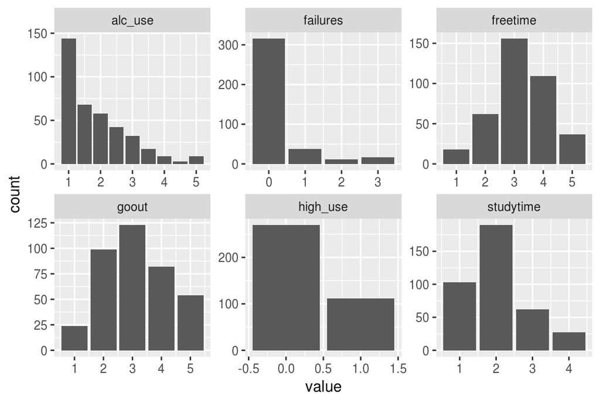

```r
gather(alc_vars) %>% ggplot(aes(value)) + geom_bar() + facet_wrap("key", scales = "free")
```

High alcohol consumption is present in ~100 observations, the vast majority of observations never failed a class, freetime is balanced for ~150 observations, going out is baanced for ~125 observations, ~100 observations study less than 2 hours per week, ~200 observations study 2 to 5 hours per week, ~50 study 5 to 10 hours per week and ~20 study more than 10 hours per week.

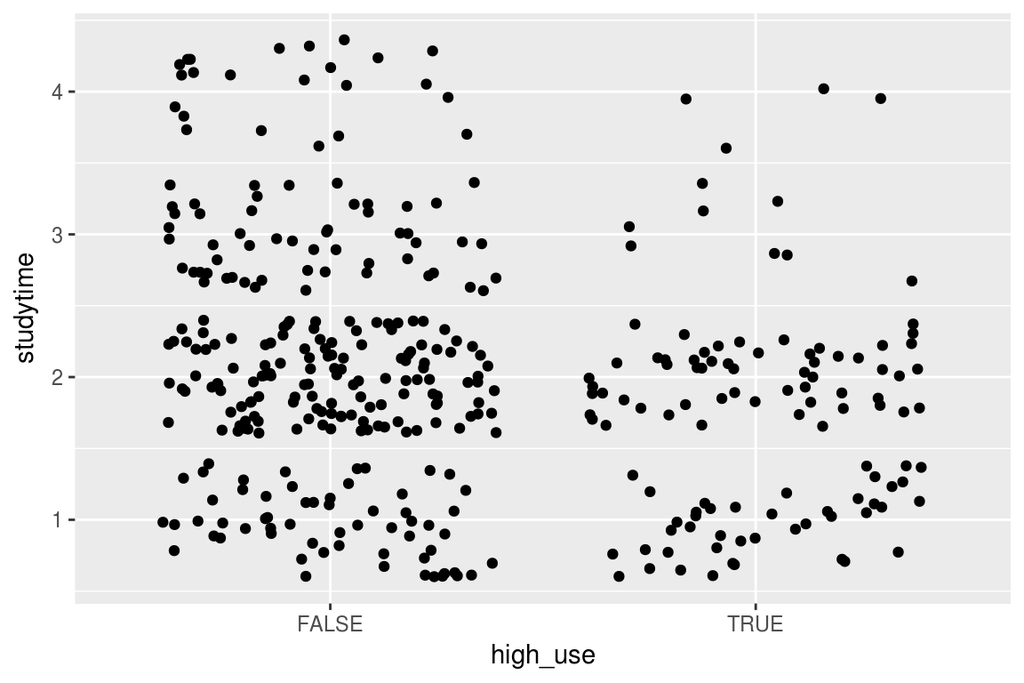

```r
ggplot(data=alc, aes(x = high_use, y = studytime)) + geom_jitter()
```

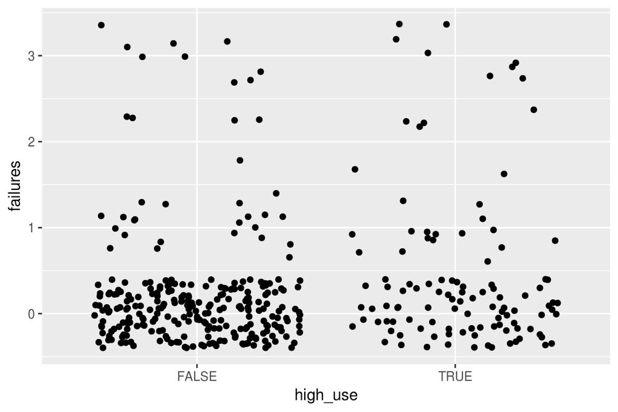

```r
ggplot(data=alc, aes(x = high_use, y = failures)) + geom_jitter()
```

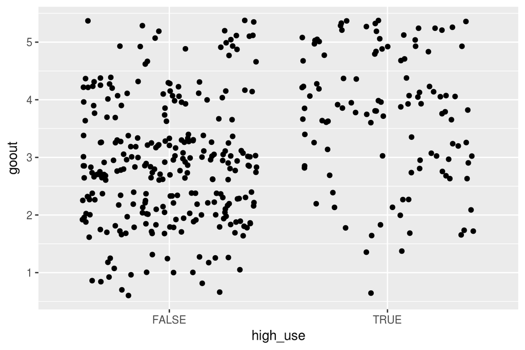

```r
ggplot(data=alc, aes(x = high_use, y = goout)) + geom_jitter()
```

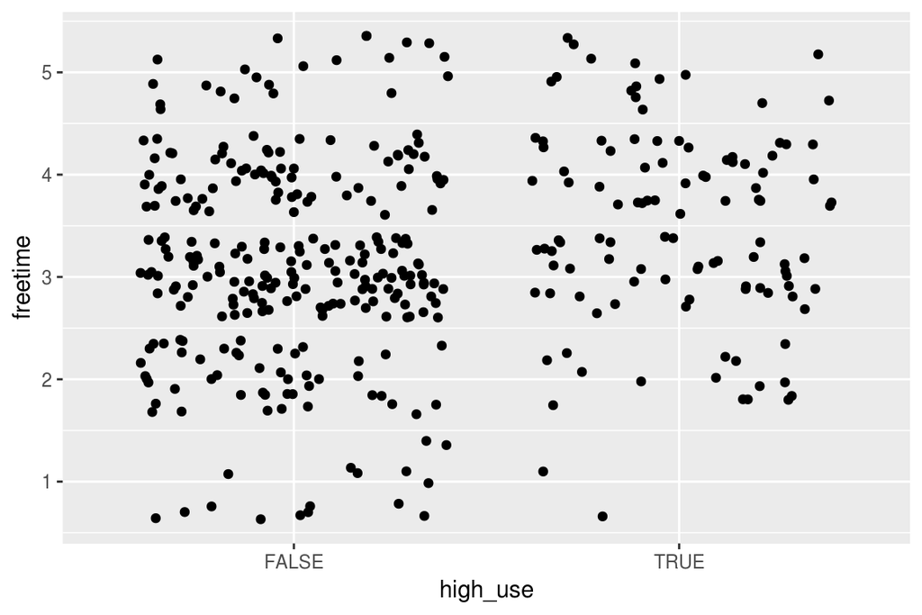

```r
ggplot(data=alc, aes(x = high_use, y = freetime)) + geom_jitter()
```

The plots seem to support my initial hypotheses, except for the variable failures (high number of failures is not associated with high alcohol consumption) and freetime (balanced freetime seems to be correlated with alcohol consumption).

```r
glm(formula = high_use ~ studytime + failures + goout + freetime, data = alc, family = "binomial") %>% summary
```

```
##
## Call:
## glm(formula = high_use ~ studytime + failures + goout + freetime,
##     family = "binomial", data = alc)
##
## Deviance Residuals:
##     Min       1Q   Median       3Q      Max
## -1.8214  -0.7528  -0.5442   0.8552   2.4579
##
## Coefficients:
##             Estimate Std. Error z value Pr(>|z|)
## (Intercept) -2.36957    0.62399  -3.797 0.000146 ***
## studytime   -0.57481    0.16784  -3.425 0.000615 ***
## failures     0.19303    0.16899   1.142 0.253334
## goout        0.70490    0.12039   5.855 4.77e-09 ***
## freetime     0.07209    0.13531   0.533 0.594163
## ---
## Signif. codes:  0 '***' 0.001 '**' 0.01 '*' 0.05 '.' 0.1 ' ' 1
##
## (Dispersion parameter for binomial family taken to be 1)
##
##     Null deviance: 462.21  on 381  degrees of freedom
## Residual deviance: 395.17  on 377  degrees of freedom
## AIC: 405.17
##
## Number of Fisher Scoring iterations: 4
```

###### IODS - Introduction to Open Data Science - 2017

# Week 2:

## Regression and model validation

### Brief explanation of the data

The dataset analysed concerns the learning experience of a set of students. Students were asked questions about their approach to studying as well as their attitude towards it. In particular 3 kinds of approach were pinpointed: deep, strategic and surface approaches. The dataset also contains personal information about the participants: gender and age. The collected data were compared to exam points.

The following command reads the data into R. As a matter of convenience, the dataset is loaded from a file on the internet, although the Data wrangling part has been completed (check file data/create_learning2014.txt and data/learning2014.txt in my github repository).

```r
learning2014 <- read.table("http://s3.amazonaws.com/assets.datacamp.com/production/course_2218/datasets/learning2014.txt", sep=",", header=TRUE)
```

Let us take a look at the structure of the dataset:

```r
str(learning2014)
```

```
## 'data.frame':    166 obs. of  7 variables:
##  $ gender  : Factor w/ 2 levels "F","M": 1 2 1 2 2 1 2 1 2 1 ...
##  $ age     : int  53 55 49 53 49 38 50 37 37 42 ...
##  $ attitude: num  3.7 3.1 2.5 3.5 3.7 3.8 3.5 2.9 3.8 2.1 ...
##  $ deep    : num  3.58 2.92 3.5 3.5 3.67 ...
##  $ stra    : num  3.38 2.75 3.62 3.12 3.62 ...
##  $ surf    : num  2.58 3.17 2.25 2.25 2.83 ...
##  $ points  : int  25 12 24 10 22 21 21 31 24 26 ...
```

The dimensions are: 166 observations and 7 variables. Those are: gender, age, attitude, deep (deep learning approach), stra (strategic learning approach), surf (surface learning approach) and points (exam grade) for each observed student.

### Graphical overview of data and summary

Using the library ‘ggplot2’, let us examine the graphical overview of our data:

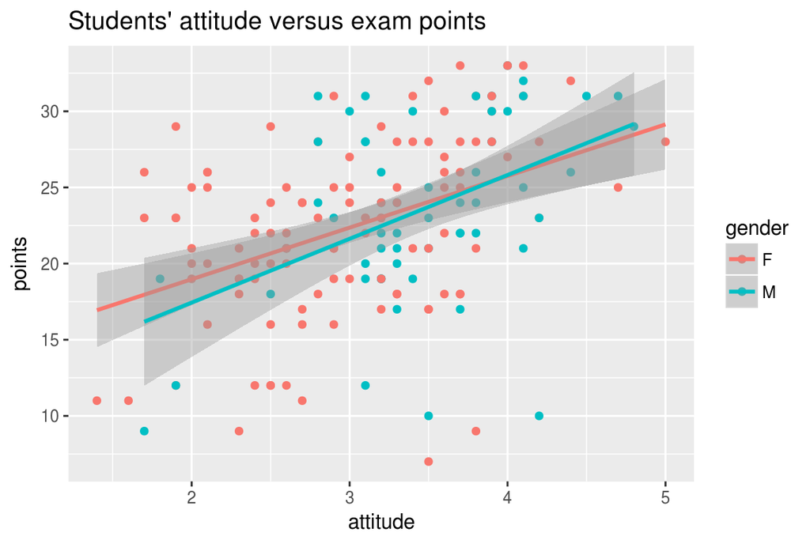

```r
library(ggplot2)
ggplot(learning2014, aes(x = attitude, y = points, col = gender)) + geom_point() + geom_smooth(method = "lm") + ggtitle("Students' attitude versus exam points")
```

The above plot displays students’ attitudes on the x-axis and and their exam points on the y-axis and shows the correlation between the two. In addition, the different colours display the students’ gender. Gender does not seem to play an important role with respect to exam points, as both female and male participants are equally distributed throughout the plot. On the other hand, the student’s attitude towards learning is crucial for what concerns exam points, showing that in general the higher the attitude, the higher the exam points.

Let us take a look at summaries for variables in our dataset with the function summary():

```r
summary(learning2014)
```

```
##  gender       age           attitude          deep            stra
##  F:110   Min.   :17.00   Min.   :1.400   Min.   :1.583   Min.   :1.250
##  M: 56   1st Qu.:21.00   1st Qu.:2.600   1st Qu.:3.333   1st Qu.:2.625
##          Median :22.00   Median :3.200   Median :3.667   Median :3.188
##          Mean   :25.51   Mean   :3.143   Mean   :3.680   Mean   :3.121
##          3rd Qu.:27.00   3rd Qu.:3.700   3rd Qu.:4.083   3rd Qu.:3.625
##          Max.   :55.00   Max.   :5.000   Max.   :4.917   Max.   :5.000
##       surf           points
##  Min.   :1.583   Min.   : 7.00
##  1st Qu.:2.417   1st Qu.:19.00
##  Median :2.833   Median :23.00
##  Mean   :2.787   Mean   :22.72
##  3rd Qu.:3.167   3rd Qu.:27.75
##  Max.   :4.333   Max.   :33.00
```

Notice that female observations are roughly double than male’s, but they are equally distributed throughout the graph, as we have seen in the previous plot. The age of paticipants is ranging between 17 and 55 years old, although the 3rd Quartile is 27.00 which indicates that the vast majority of observatons falls below the middle point in this range. Range of attitudes is 1.400 to 5.000, but the vast majoity of observations lies in the middle, between values 2 and 4. Similarly, range of exam points is 7.00 to 33.00, but the vast majority falls between values 16 and 30. This suggests that exam points may be dependent on the attitude.

We are now analysing three types of learning approaches, i.e. deep, strategic and surface learning. Deep-learning range is 1.583 to 4.917; strategic-learning range is 1.250 to 5.000; surface learning range is 1.583 to 4.333. From wider to narrower range the order is: strategic, then deep and surface last. Deep learning is the learning approach with higher summary values, followed by strategic and surface at last with the lowest values.

### Linear regression

```r
my_model <- lm(points ~ attitude + stra + deep, data = learning2014)
summary(my_model)
```

```
##
## Call:
## lm(formula = points ~ attitude + stra + deep, data = learning2014)
##
## Residuals:
##      Min       1Q   Median       3Q      Max
## -17.5239  -3.4276   0.5474   3.8220  11.5112
##
## Coefficients:
##             Estimate Std. Error t value Pr(>|t|)
## (Intercept)  11.3915     3.4077   3.343  0.00103 **
## attitude      3.5254     0.5683   6.203 4.44e-09 ***
## stra          0.9621     0.5367   1.793  0.07489 .
## deep         -0.7492     0.7507  -0.998  0.31974
## ---
## Signif. codes:  0 '***' 0.001 '**' 0.01 '*' 0.05 '.' 0.1 ' ' 1
##
## Residual standard error: 5.289 on 162 degrees of freedom
## Multiple R-squared:  0.2097, Adjusted R-squared:  0.195
## F-statistic: 14.33 on 3 and 162 DF,  p-value: 2.521e-08
```

The residuals are fairly high for what concerns min and max values, but they get closer to 0 at the median. Std. Error falls between 0 and 1 for all 3 independent variables. T value for the 3 variables is highest for attitude and lowes for deep learning, while strategic learning lies in between. A multiple R-squared of 0.2097 indicates that the model fits the data for roughly 21% of the observations.

### Residual vs. Fitted values

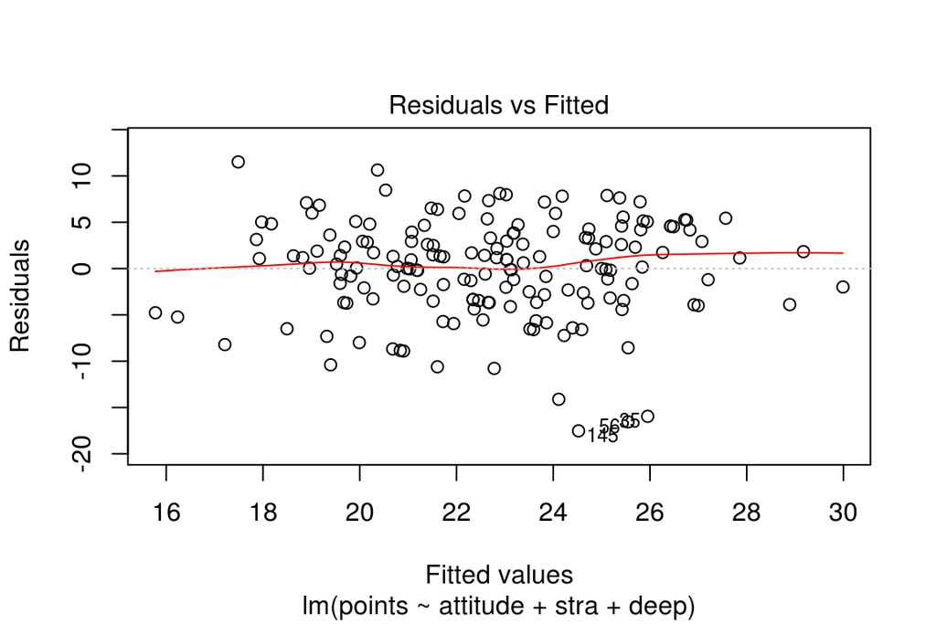

```r
plot(my_model, 1)
```

The above plot illustrates the variation around the estimated regression line. Since this variation is constant, this suggests that the assumption of equal error variances is reasonable and that the assumption that the relationship is linear is also reasonable.

### Normal QQ-plot

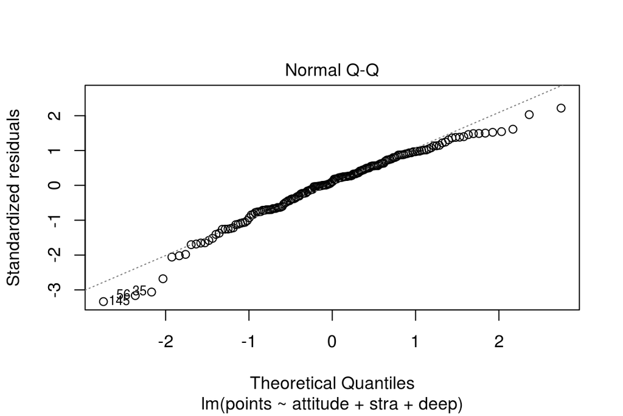

```r
plot(my_model, 2)
```

The above plot illustrates the normal distribution of our observations. Despite a tail on the left and a skew on the right, the circles in the scatterplot lie all quite close to the line, suggesting that our assumpton is plausible.

### Residuals vs. Leverage

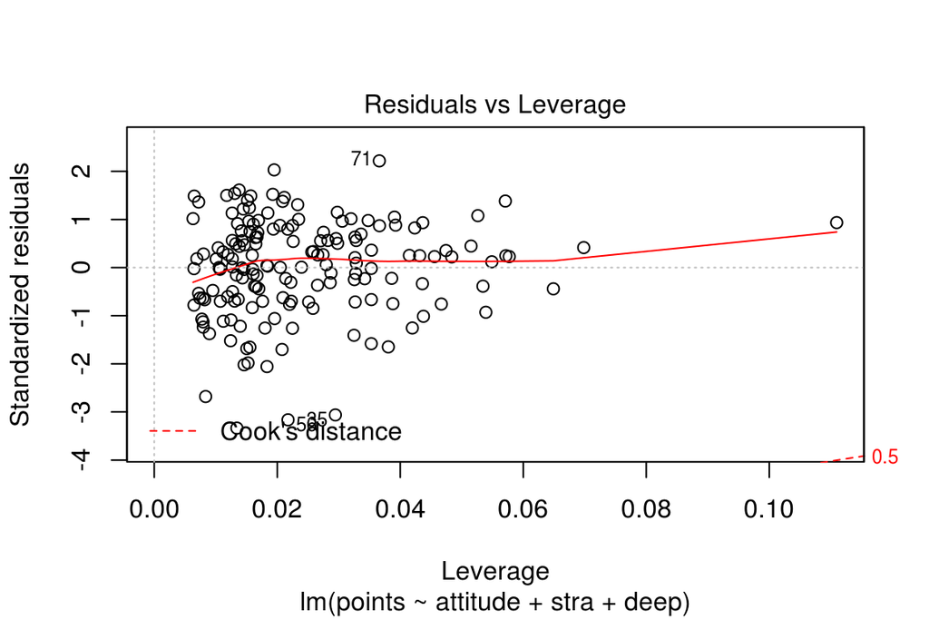

```r
plot(my_model, 5)
```

The above plot shows there are no observations that are outside Cook’s distance. Since it is not the case for high Cook’s distance, this means there are no influential cases to the regression results. This once more backs up our hypothesis for a model.

###### IODS - Introduction to Open Data Science - 2017

# Week 1:

## About the project

Link to [my GitHub repository](https://github.com/egcmi/IODS-project).

Link to [my course diary](https://egcmi.github.io/IODS-project/).

Our era of data - larger than ever and complex like chaos - requires several skills from statisticians and other data scientists. We must discover the patterns hidden behind numbers in matrices and arrays. We are not afraid of coding, recoding, programming, or modelling. We want to visualize, analyze, interpret, understand, and communicate. These are the core themes of Open Data Science (Open Data - Open Science - Data Science). And this course is THE course for learning these skills.